# Normal Region

## Normal region analyses

Here, we focus on cells belonging to the intermediate population (Cluster 3) located within the histologically normal fallopian tube, which may represent cells undergoing early transformation and therefore provides an opportunity to study the earliest stages of high-grade serous ovarian cancer development.

First, required libraries are loaded

```r
# Load libraries
library(Seurat)
library(dplyr)
library(ggplot2)
library(patchwork)
library(dbscan)
library(FNN)
```

## Data import

The Xenium object generated from the SpatialCopyInference workflow is imported. The object contains cell annotations, spatial coordinates, inferred copy number profiles and BANKSY clusters for the ovarian Xenium dataset.

```r
xenium.obj <- readRDS("Data/Xenium_ovarian.rds")
```

Next, cells belonging to the histologically normal fallopian tube region are subset for downstream analyses.

```r
# Subset normal region
box <- list(xmin = 7800, xmax = 10100, ymin = 3750, ymax = 6050)

coords <- GetTissueCoordinates(xenium.obj, image = "fov")
cells_keep <- colnames(xenium.obj)[
  coords$x > box$xmin &
  coords$x < box$xmax &
  coords$y > box$ymin &
  coords$y < box$ymax]

xenium.sub <- subset(xenium.obj, cells = cells_keep)
coords_sub <- GetTissueCoordinates(xenium.sub, image = "fov")

# Remove full Xenium object to reduce memory usage
rm(xenium.obj)
gc()
```

```
##             used   (Mb) gc trigger   (Mb)  max used   (Mb)
## Ncells   6030426  322.1   10687364  570.8  10687364  570.8
## Vcells 651327094 4969.3 1309160410 9988.2 934109410 7126.7
```

## Plot settings

```r
# Set manual colours from palette
manual_col <- c("Proliferative Tumour Cells" = "#F1CE63",
                "MT-High, Jun+/Fos+ Tumour Cells" = "#86BCB6",
                "VEGFA+ Tumour Cells" = "#FABFD2",
                "Tumour Cells" = "#D37295",
                "Fallopian Tube Epithelium" = "#59A14F",
                "Macrophages" = "#8CD17D",
                "Tumour Associated Ciliated Epithelial Cells" = "#A0CBE8",
                "Ciliated Epithelial Cells" = "#4E79A7",
                "T & NK Cells" = "#79706E",
                "Tumour Associated Fibroblasts" = "#BAB0AC",
                "Malignant Cells Lining Cyst" = "#B6992D",
                "Endothelial Cells" = "#D7B5A6",
                "Stromal Associated Fibroblasts" = "#FF9D9A",
                "Pericytes" = "#499894",
                "Smooth Muscle Cells" = "#E15759",
                "Inflammatory Tumour Cells" = "#B07AA1",
                "Granulosa Cells" = "#FFBE7D",
                "Secretory Epithelial Cells" = "#F28E2B")

# Add legend order
legend_order <- c("Tumour Cells", "Inflammatory Tumour Cells", "Proliferative Tumour Cells", "VEGFA+ Tumour Cells", "MT-High, Jun+/Fos+ Tumour Cells", "Malignant Cells Lining Cyst", "Tumour Associated Fibroblasts", "Tumour Associated Ciliated Epithelial Cells", "Fallopian Tube Epithelium", "Secretory Epithelial Cells", "Ciliated Epithelial Cells", "Granulosa Cells","Endothelial Cells", "Pericytes", "Stromal Associated Fibroblasts", "Smooth Muscle Cells", "Macrophages", "T & NK Cells")
```

## Cell type composition

Here, we investigate the spatial distribution of cells with in Cluster 3 and compare cell type composition between Cluster 3 and non-cluster 3 within the normal fallopian tube region.

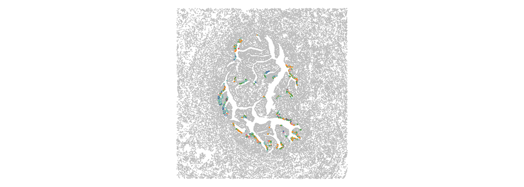

```r
# Define Cluster 3 cells
plot_df_sub <- data.frame(cell = colnames(xenium.sub),
                          x = coords_sub$x,
                          y = coords_sub$y)

cells_cluster3 <- colnames(xenium.sub)[xenium.sub$banksy_clusters == 3]

plot_df_sub$cluster3 <- plot_df_sub$cell %in% cells_cluster3

# Add cell type annotations
plot_df_sub$group <- xenium.sub$group[match(plot_df_sub$cell, colnames(xenium.sub))]

# Add Cluster 3 vs Other to object
xenium.sub$cluster3_status <- ifelse(plot_df_sub$cluster3[
    match(colnames(xenium.sub), plot_df_sub$cell)],
    "Cluster 3","Other")

# Figure 4A (left): Spatial distribution of Cluster 3 cells
ggplot(plot_df_sub, aes(x = x, y = y)) +
  geom_point(colour = "grey",
    size = 0.15) +
  geom_point(
    data = subset(plot_df_sub, cluster3),
    aes(colour = group),
    size = 0.4) +
  coord_equal() +
  scale_y_reverse() +
  theme_void() +
  scale_color_manual(values = manual_col) +
  guides(colour = guide_legend(override.aes = list(size = 3))
  ) +
  theme(legend.position = "none",
    legend.title = element_blank(),
    legend.text = element_text(size = 7))
```

## SEC enrichment

To determine whether Secretory Epithelial Cells (SECs) are enriched within Cluster 3, cell type composition is compared between Cluster 3 and all other cells in the normal fallopian tube region.

```r
# Quantify enrichment of Secretory Epithelial Cells in cluster 3
# Fisher’s exact test
ft_sec <- fisher.test(table(plot_df_sub$cluster3,
          xenium.sub$group == "Secretory Epithelial Cells"))
ft_sec
```

```
##
##  Fisher's Exact Test for Count Data
##
## data:  table(plot_df_sub$cluster3, xenium.sub$group == "Secretory Epithelial Cells")
## p-value < 2.2e-16
## alternative hypothesis: true odds ratio is not equal to 1
## 95 percent confidence interval:
##  15.14095 22.00113
## sample estimates:
## odds ratio
##   18.28028
```

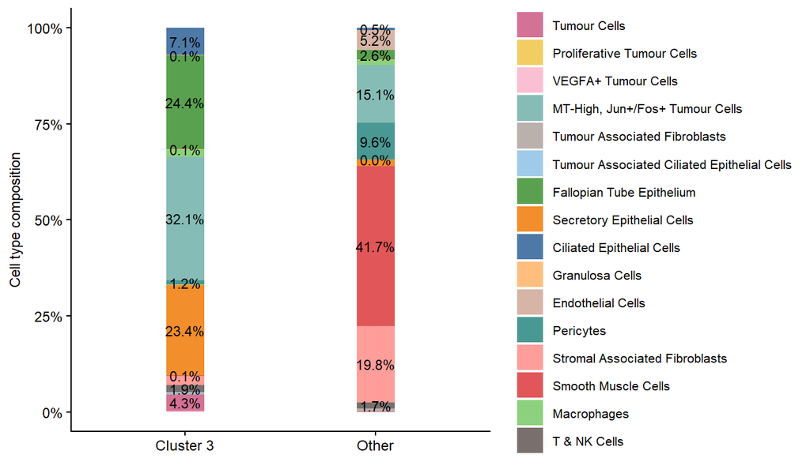

```r
# Cell type composition
bar_data <- xenium.sub@meta.data %>%
  count(cluster3_status, group) %>%
  group_by(cluster3_status) %>%
  mutate(prop = n / sum(n))

# Figure 4A (right): Cell type composition of Cluster 3 versus all other cells
ggplot(bar_data,
  aes(x = cluster3_status,
    y = prop,
    fill = group)) +
  geom_col(width = .2) +
  geom_text(aes(label = scales::percent(prop, accuracy = 0.1))
          ,position = position_stack(vjust = 0.5),
          size = 3,
          check_overlap = TRUE) +
  scale_y_continuous(labels = scales::percent_format()) +
  scale_fill_manual(values = manual_col, breaks = legend_order) +
  labs(x = NULL, y = "Cell type composition", fill = "") +
  theme_classic() +
  theme(axis.text.x=element_text(colour="black", size=9)) +
  theme(axis.text.y=element_text(colour="black", size=9)) +
  theme(axis.title.y=element_text(colour="black", size=9)) +
  theme(legend.text=element_text(colour="black", size=8))
```

## TP53 high analyses

Here, TP53 expression is used to define TP53-high cells within the normal fallopian tube region.

```r
# Fetch TP53 expression
expr_sub <- FetchData(xenium.sub, vars = "TP53", layer = "data")

plot_df_sub$TP53 <- expr_sub$TP53

# Plot TP53 expression and distribution
TP53_spatial <- ggplot(plot_df_sub, aes(x = x, y = y, col = TP53)) +
    geom_point(size = 0.3) +
    coord_equal() +
    scale_y_reverse() +
    theme_void() +
    scale_colour_gradient(low = "lightgrey", high = "blue") +
    ggtitle("TP53")

TP53_dist_incl_zeroes <- ggplot(plot_df_sub, aes(x = "", y = TP53)) +
                              geom_violin(fill = "lightblue", trim = FALSE) +
                              geom_boxplot(width = 0.1, color = "black", fill = "white") +
                              theme_minimal() +
                              labs(title = "TP53 expression",
                                   x = "",
                                   y = "Log-normalised expression")

plot_df_nonzero <- subset(plot_df_sub, TP53 > 0)

TP53_dist_excl_zeroes <- ggplot(plot_df_nonzero, aes(x = "", y = TP53)) +
                    geom_violin(fill = "lightblue", trim = FALSE) +
                    geom_boxplot(width = 0.1, color = "black", fill = "white") +
                    theme_minimal() +
                    labs(title = "TP53 expression (non-zero only)",
                         x = "",
                         y = "Log-normalised expression")

# Define TP53-high cells
low_threshold <- quantile(plot_df_nonzero$TP53, 0.1)
low_threshold
```

```
##      10%
## 4.823112
```

```r
plot_df_sub$TP53_high <- plot_df_sub$TP53 > low_threshold

table(plot_df_sub$TP53_high)
```

```
##
## FALSE  TRUE
## 34066   845
```

```r
# Spatial distribution of TP53-high cells
TP53_high <- ggplot(plot_df_sub, aes(x = x, y = y, col = TP53_high)) +
            geom_point(size = 0.3) +
            coord_equal() +
            scale_y_reverse() +
            theme_void() +
            scale_color_manual(values = c("grey", "red")) +
            ggtitle("High TP53 cells")
```

### Plots TP53

#### TP53 expression

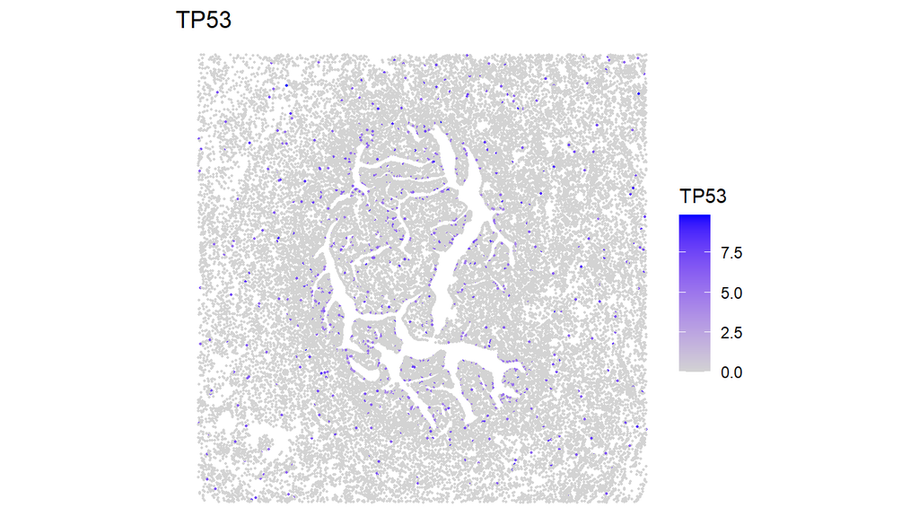

```r
TP53_spatial
```

#### TP53 distribution

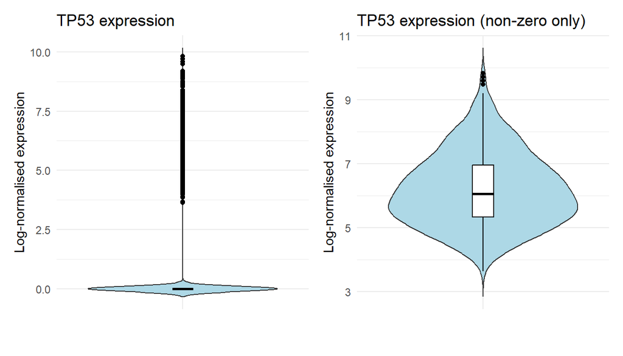

```r
(TP53_dist_incl_zeroes | TP53_dist_excl_zeroes)
```

#### TP53-high classification

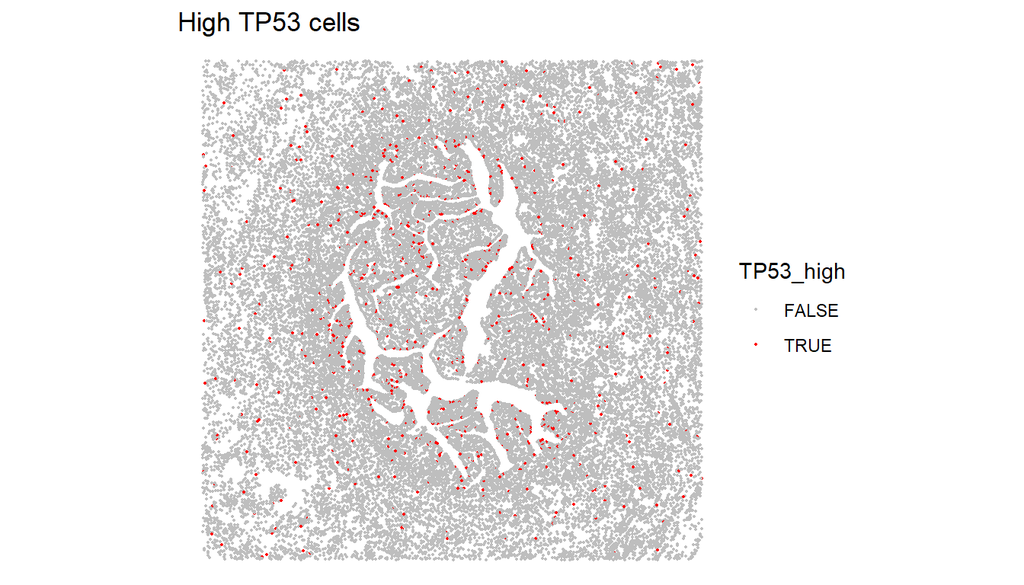

```r
TP53_high
```

### TP53-high in Cluster 3

Here, we investigate whether TP53 high cells are enriched in cluster 3. Then we compare TP53 high cells vs TP53 low cells within cluster 3.

```r
# TP53-high enrichment Cluster 3
tbl <- table(Cluster_3 = plot_df_sub$cluster3,TP53_high = plot_df_sub$TP53_high)
ft_tp53_c3 <- fisher.test(tbl)
ft_tp53_c3
```

```
##
##  Fisher's Exact Test for Count Data
##
## data:  tbl
## p-value < 2.2e-16
## alternative hypothesis: true odds ratio is not equal to 1
## 95 percent confidence interval:
##  3.966187 6.466943
## sample estimates:
## odds ratio
##   5.089958
```

```r
# Define TP53-high and TP53-low cells within Cluster 3
plot_df_sub$TP53_c3_status <- NA

plot_df_sub$TP53_c3_status[plot_df_sub$cluster3
              & plot_df_sub$TP53_high] <- "TP53high_cluster3"

plot_df_sub$TP53_c3_status[plot_df_sub$cluster3
              & !plot_df_sub$TP53_high] <- "TP53low_cluster3"

# Add classification to object
xenium.sub$TP53_c3_status <- plot_df_sub$TP53_c3_status[
  match(colnames(xenium.sub), plot_df_sub$cell)]

table(xenium.sub$TP53_c3_status)
```

```
##
## TP53high_cluster3  TP53low_cluster3
##                84               723
```

```r
# Restrict to Cluster 3 cells
xenium.c3 <- subset(xenium.sub, subset = !is.na(TP53_c3_status))
Idents(xenium.c3) <- "TP53_c3_status"

# Differential expression
markers_tp53_c3 <- FindMarkers(
  xenium.c3,
  ident.1 = "TP53high_cluster3",
  ident.2 = "TP53low_cluster3")

# Significant upregulated genes
markers_tp53_c3_sig <- subset(markers_tp53_c3,
  p_val_adj < 0.05 & avg_log2FC > 0)

head(markers_tp53_c3_sig, 10)
```

```
##              p_val avg_log2FC pct.1 pct.2     p_val_adj
## TP53 5.645961e-121   5.687052 1.000 0.065 2.873794e-117
## MET   9.769469e-06   2.213942 0.107 0.021  4.972660e-02
```

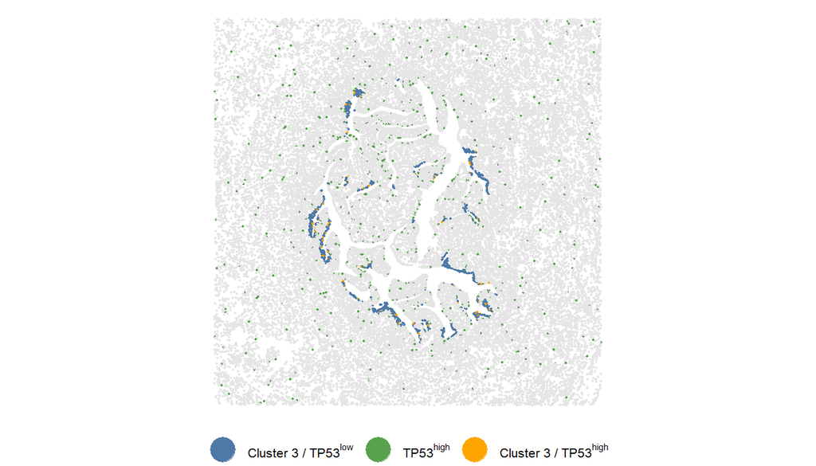

```r
# Figure 4B: Spatial distribution of TP53-high cells Cluster 3
plot_df_sub$state <- "Neither"

plot_df_sub$state[
  plot_df_sub$cluster3 & !plot_df_sub$TP53_high
] <- "Cluster 3"

plot_df_sub$state[
  !plot_df_sub$cluster3 & plot_df_sub$TP53_high
] <- "TP53+"

plot_df_sub$state[
  plot_df_sub$cluster3 & plot_df_sub$TP53_high
] <- "Both"

ggplot(plot_df_sub,
       aes(x = x, y = y, colour = state)) +
  geom_point(size = .3) +
  coord_equal() +
  scale_y_reverse() +
  theme_void() +
  scale_colour_manual(
  values = c(
    "Neither"   = "grey90",
    "Cluster 3" = "#4E79A7",
    "TP53+"     = "#59A14F",
    "Both"      = "orange"
  ),
  breaks = c("Cluster 3", "TP53+", "Both"),
  labels = c(
        expression("Cluster 3 / " * TP53^low),
    expression(TP53^high),
    expression("Cluster 3 / " * TP53^high)
  )
) +
  theme(legend.position = "bottom",
    legend.title = element_blank(),
    legend.text = element_text(size = 8)
  ) +
  guides(colour = guide_legend(
      override.aes = list(size = 7)
    )
  )
```

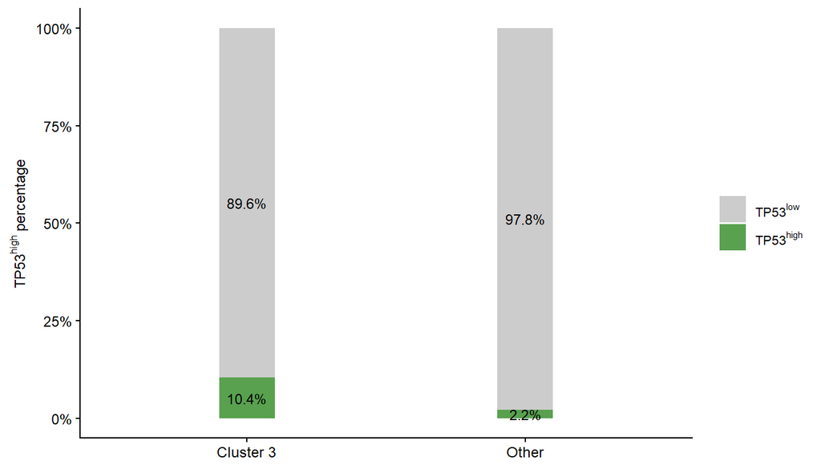

```r
# Figure 4B: TP53-high enrichment Cluster 3
bar_df_enr <- as.data.frame(prop.table(tbl, margin = 1))
bar_df_enr$Cluster_3 <- factor(
  bar_df_enr$Cluster_3,
  levels = c(TRUE, FALSE),
  labels = c("Cluster 3", "Other"))

ggplot(bar_df_enr,
  aes(x = Cluster_3,
    y = Freq,
    fill = TP53_high)) +
  geom_col(width = 0.2) +
  geom_text(aes(label = scales::percent(Freq, accuracy = 0.1) ),
    position = position_stack(vjust = 0.5),
    size = 3) +
    scale_fill_manual(values = c("FALSE" = "grey80",
    "TRUE" = "#59A14F"),
  labels = c( expression(TP53^"low"), expression(TP53^"high"))
  ) +
  scale_y_continuous(labels = scales::percent) +
  theme_classic() +
  labs(x = NULL,  y = expression(TP53^"high" ~ "percentage"), fill = NULL) +
  theme(axis.text.x=element_text(colour="black", size=9)) +
  theme(axis.text.y=element_text(colour="black", size=9)) +
  theme(axis.title.y=element_text(colour="black", size=9)) +
    theme(legend.text=element_text(colour="black", size=8))
```

### TP53 target gene activity by Cluster 3 status

```r
# Top 10 p53 target genes from Fischer et al.
# https://www.nature.com/articles/onc2016502#Tab1
func_p53_genes <- c("CDKN1A", "RRM2B", "MDM2", "SUSD6", "GDF15",
                     "BTG2", "DDB2", "GADD45A", "PLK3", "TIGAR")

func_p53_genes_present <- intersect(func_p53_genes,
  rownames(xenium.sub))

func_p53_genes_present
```

```
## [1] "CDKN1A"  "MDM2"    "GDF15"   "DDB2"    "GADD45A"
```

```r
# Calculate module score
xenium.sub <- AddModuleScore(xenium.sub,
  features = list(func_p53_genes_present),
  name = "targets_p53")

Module_TP53_C3 <- FetchData(
  xenium.sub,
  vars = c("targets_p531",
    "cluster3_status"))

# Summary statistics
aggregate(
  targets_p531 ~ cluster3_status,
  data = Module_TP53_C3,
  FUN = median
)
```

```
##   cluster3_status targets_p531
## 1       Cluster 3   -0.3667621
## 2           Other   -0.1677064
```

```r
# Statistical test
wt_tp53_c3 <- wilcox.test(targets_p531 ~ cluster3_status,
  data = Module_TP53_C3, conf.int = TRUE)
wt_tp53_c3
```

```
##
##  Wilcoxon rank sum test with continuity correction
##
## data:  targets_p531 by cluster3_status
## W = 9960472, p-value < 2.2e-16
## alternative hypothesis: true location shift is not equal to 0
## 95 percent confidence interval:
##  -0.2161632 -0.1708683
## sample estimates:
## difference in location
##             -0.1940546
```

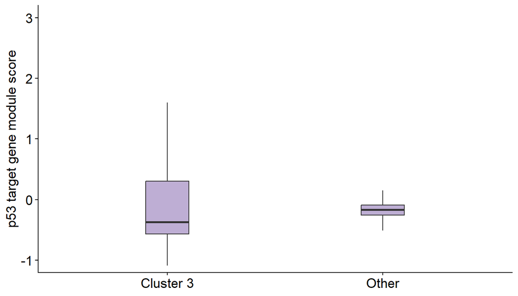

```r
# Figure 4C: TP53 target gene module score comparing Cluster 3 and other cells
ggplot(
  Module_TP53_C3,
  aes(
    x = cluster3_status,
    y = targets_p531,
    fill = cluster3_status
  )
) +
  geom_boxplot(
    width = 0.2,
    outlier.shape = NA
  ) +
  theme_classic() +
  labs(
    x = NULL,
    y = "p53 target gene module score"
  ) +
  theme(
    legend.position = "none",
    axis.text.x = element_text(colour = "black", size = 13),
    axis.text.y = element_text(colour = "black", size = 13),
    axis.title.y = element_text(colour = "black", size = 13)
  ) +
  scale_fill_manual(
    values = c(
      "Other" = "#beaed4",
      "Cluster 3" = "#beaed4"
    )
  ) +
  coord_cartesian(
    ylim = c(-1, 3)
  )
```

### TP53 target gene activity by TP53 status

Here, p53 target gene activity is compared across TP53-high and TP53-low cells within and outside Cluster 3.

```r
# Define groups
plot_df_sub$TP53_cluster_group <- NA

plot_df_sub$TP53_cluster_group[
  plot_df_sub$cluster3 & plot_df_sub$TP53_high
] <- "TP53high_C3"

plot_df_sub$TP53_cluster_group[
  plot_df_sub$cluster3 & !plot_df_sub$TP53_high
] <- "TP53low_C3"

plot_df_sub$TP53_cluster_group[
  !plot_df_sub$cluster3 & plot_df_sub$TP53_high
] <- "TP53high_nonC3"

plot_df_sub$TP53_cluster_group[
  !plot_df_sub$cluster3 & !plot_df_sub$TP53_high
] <- "TP53low_nonC3"

# Add to object
xenium.sub$TP53_cluster_group <- plot_df_sub$TP53_cluster_group[
  match(colnames(xenium.sub), plot_df_sub$cell)
]

table(xenium.sub$TP53_cluster_group)
```

```
##
##    TP53high_C3 TP53high_nonC3     TP53low_C3  TP53low_nonC3
##             84            761            723          33343
```

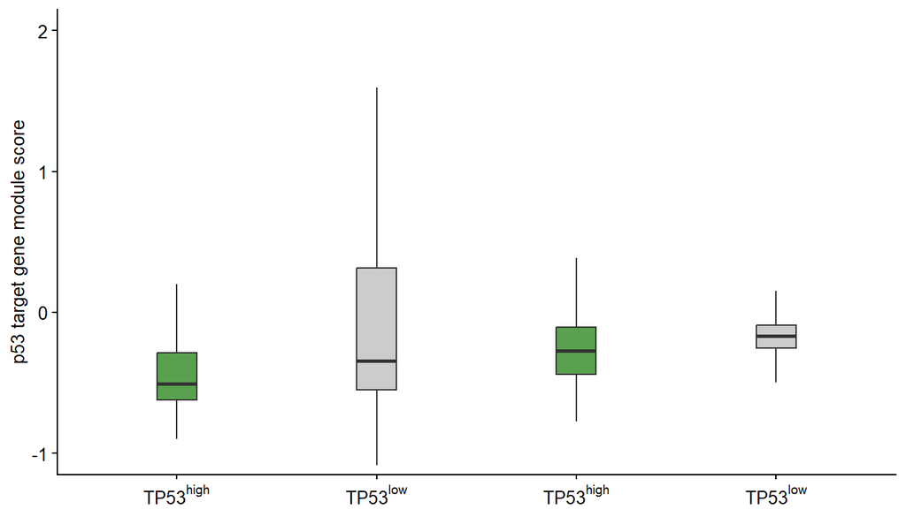

```r
Module_TP53 <- FetchData(
  xenium.sub,
  vars = c("targets_p531", "TP53_cluster_group")
)

Module_TP53$TP53_cluster_group <- factor(
  Module_TP53$TP53_cluster_group,
  levels = c("TP53high_C3", "TP53low_C3",
    "TP53high_nonC3", "TP53low_nonC3")
)

# Supplementary Figure 4: TP53 target gene activity by TP53 and Cluster 3 status
ggplot(
  Module_TP53,
  aes(
    x = TP53_cluster_group,
    y = targets_p531,
    fill = TP53_cluster_group
  )
) +
  geom_boxplot(
    width = 0.2,
    outlier.shape = NA
  ) +
  theme_classic() +
  labs(
    x = NULL,
    y = "p53 target gene module score"
  ) +
  scale_fill_manual(
    values = c(
      "TP53low_nonC3"  = "grey80",
      "TP53high_nonC3" = "#59A14F",
      "TP53low_C3"     = "grey80",
      "TP53high_C3"    = "#59A14F"
    )
  ) +
  scale_x_discrete(
    labels = c(
      "TP53low_nonC3"  = expression(TP53^"low"),
      "TP53high_nonC3" = expression(TP53^"high"),
      "TP53low_C3"     = expression(TP53^"low"),
      "TP53high_C3"    = expression(TP53^"high")
    )
  ) +
  theme(
    legend.position = "none",
    axis.text.x = element_text(
      colour = "black",
      size = 10
    ),
    axis.text.y = element_text(
      colour = "black",
      size = 10
    ),
    axis.title.y = element_text(
      colour = "black",
      size = 10
    )
  ) + coord_cartesian(ylim = c(-1, 2))
```

```r
# Summary statistics
aggregate(targets_p531 ~ TP53_cluster_group,
  data = Module_TP53,
  median)
```

```
##   TP53_cluster_group targets_p531
## 1        TP53high_C3   -0.5062855
## 2         TP53low_C3   -0.3461284
## 3     TP53high_nonC3   -0.2721706
## 4      TP53low_nonC3   -0.1668191
```

```r
kt_tp53 <- kruskal.test(targets_p531 ~ TP53_cluster_group,
  data = Module_TP53)
kt_tp53
```

```
##
##  Kruskal-Wallis rank sum test
##
## data:  targets_p531 by TP53_cluster_group
## Kruskal-Wallis chi-squared = 344.53, df = 3, p-value < 2.2e-16
```

```r
pw_tp53 <- pairwise.wilcox.test(Module_TP53$targets_p531,
  Module_TP53$TP53_cluster_group,
  p.adjust.method = "BH")
pw_tp53
```

```
##
##  Pairwise comparisons using Wilcoxon rank sum test with continuity correction
##
## data:  Module_TP53$targets_p531 and Module_TP53$TP53_cluster_group
##
##                TP53high_C3 TP53low_C3 TP53high_nonC3
## TP53low_C3     0.00290     -          -
## TP53high_nonC3 1.1e-08     0.00024    -
## TP53low_nonC3  < 2e-16     < 2e-16    < 2e-16
##
## P value adjustment method: BH
```

## Secretory epithelial cells Cluster 3

Secretory epithelial cells (SECs) within Cluster 3 are compared to all other SECs within the normal fallopian tube region.

```r
# Identify Secretory Epithelial Cells
cells_secretory <- colnames(xenium.sub)[xenium.sub$group == "Secretory Epithelial Cells"]

plot_df_sub$Secretory <- plot_df_sub$cell %in% cells_secretory

# Define SECs inside and outside Cluster 3
plot_df_sub$classify_secretory_c3 <- NA

plot_df_sub$classify_secretory_c3[
  plot_df_sub$Secretory &
  plot_df_sub$cluster3
] <- "Secretory_cluster3"

plot_df_sub$classify_secretory_c3[
  plot_df_sub$Secretory &
  !plot_df_sub$cluster3
] <- "Secretory_not_cluster3"

table(plot_df_sub$classify_secretory_c3, useNA = "ifany")
```

```
##
##     Secretory_cluster3 Secretory_not_cluster3                   <NA>
##                    189                    561                  34161
```

```r
# Add classification to Seurat object
xenium.sub$Secretory_cluster3_status <-
  plot_df_sub$classify_secretory_c3[
    match(colnames(xenium.sub), plot_df_sub$cell)
  ]

table(xenium.sub$Secretory_cluster3_status, useNA = "ifany")
```

```
##
##     Secretory_cluster3 Secretory_not_cluster3                   <NA>
##                    189                    561                  34161
```

```r
# Restrict analysis to SECs
xenium.secretory <- subset(
  xenium.sub,
  subset = !is.na(Secretory_cluster3_status)
)
Idents(xenium.secretory) <- "Secretory_cluster3_status"

table(Idents(xenium.secretory))
```

```
##
## Secretory_not_cluster3     Secretory_cluster3
##                    561                    189
```

```r
# Differential expression
markers_secretory_c3 <- FindMarkers(
  xenium.secretory,
  ident.1 = "Secretory_cluster3",
  ident.2 = "Secretory_not_cluster3",
  min.pct = 0.05
)

# Significant upregulated genes
markers_secretory_c3_sig <- subset(
  markers_secretory_c3,
  p_val_adj < 0.05 &
  avg_log2FC > 0
)

head(markers_secretory_c3_sig, 10)
```

```
##             p_val avg_log2FC pct.1 pct.2  p_val_adj
## ATF3 3.633904e-06  0.6667854 0.566 0.357 0.01849657
```

## SEC immune microenvironment

Here, neighbourhood analysis of the immune microenvironment of SECs within cluster 3 vs outside cluster 3 (Other) is investigated.

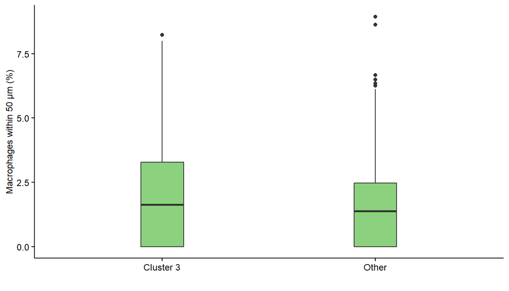

```r
# Restrict to SECs
secretory_cells <- plot_df_sub %>%
  filter(!is.na(classify_secretory_c3))

# Create neighbourhood graph
radius <- 50

coords_all <- as.matrix(
  plot_df_sub[, c("x", "y")]
)

nn_radius <- frNN(
  coords_all,
  eps = radius
)

# Identify immune cells
macrophage_ids <- which(plot_df_sub$group == "Macrophages")
tnk_ids <- which(plot_df_sub$group == "T & NK Cells")

# Count neighbouring immune cells
count_neighbours <- function(cell_id, target_ids){

  idx <- match(
    cell_id,
    plot_df_sub$cell
  )

  neigh_idx <- setdiff(
    nn_radius$id[[idx]],
    idx
  )

  sum(neigh_idx %in% target_ids)
}

secretory_cells$mac_count_50um <- sapply(
  secretory_cells$cell,
  count_neighbours,
  target_ids = macrophage_ids
)

secretory_cells$tnk_count_50um <- sapply(
  secretory_cells$cell,
  count_neighbours,
  target_ids = tnk_ids
)

# Total neighbours for density normalisation
secretory_cells$total_neighbours_50um <- sapply(
  secretory_cells$cell,
  function(cell_id){

    idx <- match(cell_id, plot_df_sub$cell)

    length(
      setdiff(
        nn_radius$id[[idx]],
        idx
      )
    )
  }
)

# Neighbourhood composition
secretory_cells$mac_pct_50um <-
  100 * secretory_cells$mac_count_50um /
  pmax(secretory_cells$total_neighbours_50um, 1)

secretory_cells$tnk_pct_50um <-
  100 * secretory_cells$tnk_count_50um /
  pmax(secretory_cells$total_neighbours_50um, 1)

# Plotting labels
secretory_cells$classify_secretory_c3 <- factor(
  secretory_cells$classify_secretory_c3,
  levels = c("Secretory_cluster3", "Secretory_not_cluster3"
  ),
  labels = c("Cluster 3", "Other")
)

# Figure 4E: SEC immune composition Macrophages
ggplot(
  secretory_cells,
  aes(
    classify_secretory_c3,
    mac_pct_50um,
    fill = classify_secretory_c3
  )
) +
  geom_boxplot(width = 0.2, fill = "#8CD17D") +
  labs(
    x = "",
    y = "Macrophages within 50 μm (%)"
  )+
  theme_classic() +
  theme(axis.text.x=element_text(colour="black", size=9)) +
  theme(axis.text.y=element_text(colour="black", size=9)) +
  theme(axis.title.y=element_text(colour="black", size=9)) +
  theme(legend.text=element_text(colour="black", size=9)) +
  theme(legend.title=element_text(colour="black", size=9))
```

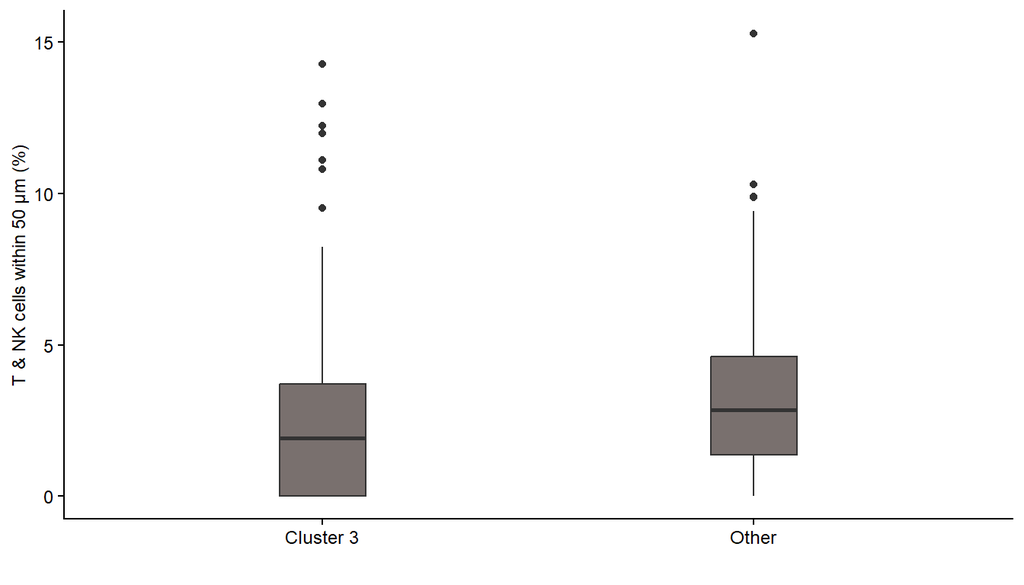

```r
# Figure 4E: SEC immune composition T & NK killer cells
ggplot(
  secretory_cells,
  aes(
    classify_secretory_c3,
    tnk_pct_50um,
    fill = classify_secretory_c3
  )
) +
  geom_boxplot(width = 0.2, fill = "#79706E") +
  labs(
    x = "",
    y = "T & NK cells within 50 μm (%)"
  ) +
  theme_classic() +
  theme(axis.text.x=element_text(colour="black", size=9)) +
  theme(axis.text.y=element_text(colour="black", size=9)) +
  theme(axis.title.y=element_text(colour="black", size=9)) +
  theme(legend.text=element_text(colour="black", size=9)) +
  theme(legend.title=element_text(colour="black", size=9))
```

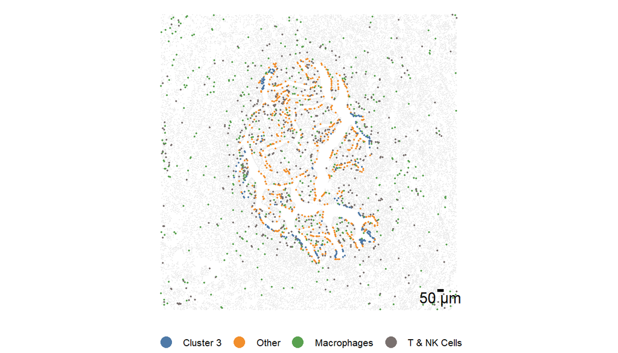

```r
# Spatial visualisation
macrophages <- plot_df_sub %>%
  filter(group == "Macrophages")

tnk_cells <- plot_df_sub %>%
  filter(group == "T & NK Cells")

plot_cells <- bind_rows(

  secretory_cells %>%
    mutate(cell_type = as.character(classify_secretory_c3)),

  macrophages %>%
    mutate(cell_type = "Macrophages"),

  tnk_cells %>%
    mutate(cell_type = "T & NK Cells")
)

x0 <- max(plot_df_sub$x) - 150
y0 <- max(plot_df_sub$y) + 100

# Figure 4E: Spatial distribution of immune microenvironment surrounding SECs
ggplot() +
  geom_point(
    data = plot_df_sub,
    aes(x, y),
    colour = "grey92",
    size = 0.1
  ) +
  geom_point(
    data = plot_cells,
    aes(x, y, colour = cell_type),
    size = 0.4
  ) +
    scale_y_reverse() +
coord_equal() +
scale_colour_manual(
  breaks = c(
    "Cluster 3",
    "Other",
    "Macrophages",
    "T & NK Cells"
  ),
  values = c(
    "Macrophages" = "#59A14F",
    "T & NK Cells" = "#79706E",
    "Cluster 3" = "#4E79A7",
    "Other" = "#F28E2B"
  )
  ) +
    annotate(
    "segment",
    x = x0,
    xend = x0 + 50,
    y = y0-250,
    yend = y0-250,
    linewidth = 1.2,
    colour = "black"
  ) +
  annotate(
    "text",
    x = x0 + 25,
    y = y0 -200,
    label = "50 μm",
    size =4.4
  ) +
    theme_void()  +
    theme(legend.position = "bottom",
          legend.title = element_blank(),
          legend.text = element_text(size = 8)) +
    guides(colour = guide_legend(
        override.aes = list(size = 4)))
```

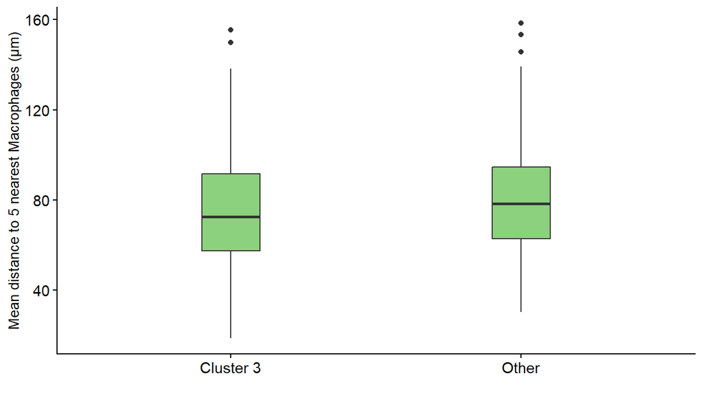

```r
# Distance metric
# Secretory cell coordinates
sec_coords <- as.matrix(
  secretory_cells[, c("x", "y")]
)

# Macrophages
mac_coords <- as.matrix(
  plot_df_sub %>%
    filter(group == "Macrophages") %>%
    select(x, y)
)

nn_mac5 <- get.knnx(
  data = mac_coords,
  query = sec_coords,
  k = 5
)

secretory_cells$mean_dist_mac5 <-
  rowMeans(nn_mac5$nn.dist)

# T & NK cells
tnk_coords <- as.matrix(
  plot_df_sub %>%
    filter(group == "T & NK Cells") %>%
    select(x, y)
)

nn_tnk5 <- get.knnx(
  data = tnk_coords,
  query = sec_coords,
  k = 5
)

secretory_cells$mean_dist_tnk5 <-
  rowMeans(nn_tnk5$nn.dist)

# Figure 4E: SEC immune proximity Macrophages
ggplot(
  secretory_cells,
  aes(
    classify_secretory_c3,
    mean_dist_mac5,
    fill = classify_secretory_c3
  )
) +
  geom_boxplot(width = 0.2, fill = "#8CD17D") +
  labs(
    x = "",
    y = "Mean distance to 5 nearest Macrophages (μm)"
  ) +
  theme_classic() +
  theme(axis.text.x=element_text(colour="black", size=11)) +
  theme(axis.text.y=element_text(colour="black", size=11)) +
  theme(axis.title.y=element_text(colour="black", size=10)) +
  theme(legend.text=element_text(colour="black", size=11)) +
  theme(legend.title=element_text(colour="black", size=11))
```

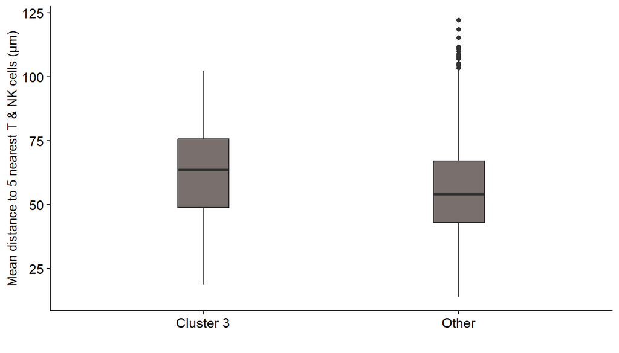

```r
# Figure 4E: SEC immune proximity T & NK killer cells
ggplot(
  secretory_cells,
  aes(
    classify_secretory_c3,
    mean_dist_tnk5,
    fill = classify_secretory_c3
  )
) +
  geom_boxplot(width = 0.2, fill = "#79706E") +
  labs(
    x = "",
    y = "Mean distance to 5 nearest T & NK cells (μm)"
  ) +
  theme_classic() +
  theme(axis.text.x=element_text(colour="black", size=11)) +
  theme(axis.text.y=element_text(colour="black", size=11)) +
  theme(axis.title.y=element_text(colour="black", size=10)) +
  theme(legend.text=element_text(colour="black", size=11)) +
  theme(legend.title=element_text(colour="black", size=11))
```

```r
# Statistical summary
p_mac_pct <- wilcox.test(
  mac_pct_50um ~ classify_secretory_c3,
  data = secretory_cells
)$p.value

p_tnk_pct <- wilcox.test(
  tnk_pct_50um ~ classify_secretory_c3,
  data = secretory_cells
)$p.value

p_mac_dist <- wilcox.test(
  mean_dist_mac5 ~ classify_secretory_c3,
  data = secretory_cells
)$p.value

p_tnk_dist <- wilcox.test(
  mean_dist_tnk5 ~ classify_secretory_c3,
  data = secretory_cells
)$p.value

results <- data.frame(
  test = c(
    "Macrophage % within 50 μm",
    "T & NK % within 50 μm",
    "Mean distance to 5 nearest macrophages",
    "Mean distance to 5 nearest T & NK cells"
  ),
  p_value = c(
    p_mac_pct,
    p_tnk_pct,
    p_mac_dist,
    p_tnk_dist
  )
)

results$FDR <- p.adjust(
  results$p_value,
  method = "BH"
)

results
```

```
##                                      test      p_value          FDR
## 1               Macrophage % within 50 μm 9.347602e-03 1.246347e-02
## 2                   T & NK % within 50 μm 1.258284e-03 2.516567e-03
## 3  Mean distance to 5 nearest macrophages 2.651550e-02 2.651550e-02
## 4 Mean distance to 5 nearest T & NK cells 6.893918e-06 2.757567e-05
```

## Co-localisation SCNAs

Here, co-localisation of SCNAs are investigated within the normal fallopian tube region, with a particular focus on chromosome arms 3q and 8q.

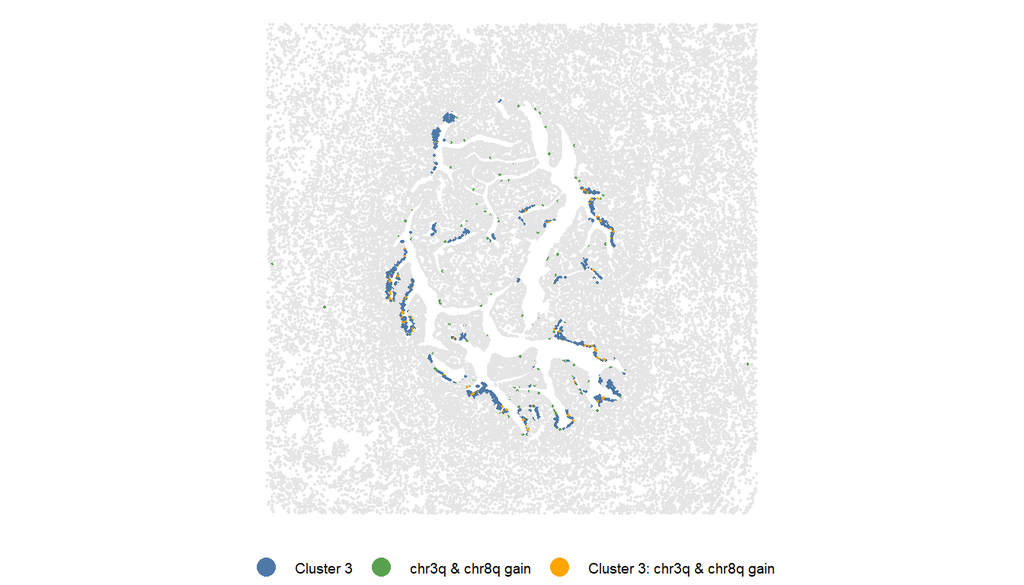

```r
# Load chromosome arm log ratios from SpatialCopyInference workflow
arm_ratios <- readRDS("Data/arm_ratios_ovarian.rds")

# Convert chromosome arm matrix to dataframe
arm_means_df <- as.data.frame(t(arm_ratios))

# Restrict to cells present in the normal region subset
arm_means_df_sub <- arm_means_df[rownames(arm_means_df) %in% colnames(xenium.sub), ]

# Define chromosome arm gains
threshold <- 0.1
chr3q_pos_sub <- arm_means_df_sub$chr3_q >= threshold
chr8q_pos_sub <- arm_means_df_sub$chr8_q >= threshold

# Create analysis dataframe
coords_sub <- GetTissueCoordinates(xenium.sub, image = "fov")

co_plot_sub <- data.frame(
  cell = colnames(xenium.sub),
  x = coords_sub$x,
  y = coords_sub$y,
  cluster3 = colnames(xenium.sub) %in% cells_cluster3,
  chr3 = chr3q_pos_sub,
  chr8 = chr8q_pos_sub
)

co_plot_sub <- co_plot_sub %>%
  mutate(
    region = ifelse(
      cluster3,
      "Cluster 3",
      "Other"
    ),
    status = case_when(
      chr3 & chr8  ~ "chr3q & chr8q gain",
      chr3 & !chr8 ~ "chr3q gain only",
      !chr3 & chr8 ~ "chr8q gain only",
      TRUE         ~ "Neither"
    ),
    both_gains = chr3 & chr8,
    neither = !(chr3 | chr8)
  )

co_plot_sub <- co_plot_sub %>%
  mutate(
    coloc_state = case_when(
      chr3 & chr8 & cluster3 ~ "Cluster 3: chr3q & chr8q gain",
      chr3 & chr8 ~ "chr3q & chr8q gain",
      cluster3 ~ "Cluster 3",
      TRUE ~ "Other"
    )
  )

# Enrichment tests: Cluster 3 versus Other
ft_chr3 <- fisher.test(
  table(
    Cluster3 = co_plot_sub$cluster3,
    Chr3gain = co_plot_sub$chr3
  )
)

ft_chr8 <- fisher.test(
  table(
    Cluster3 = co_plot_sub$cluster3,
    Chr8gain = co_plot_sub$chr8
  )
)

ft_both <- fisher.test(
  table(
    Cluster3 = co_plot_sub$cluster3,
    BothGains = co_plot_sub$both_gains
  )
)

ft_neither <- fisher.test(
  table(
    Cluster3 = co_plot_sub$cluster3,
    Neither = co_plot_sub$neither
  )
)

# Figure 4D: Spatial distribution of chr3q and chr8q gains
ggplot(
  co_plot_sub,
  aes(
    x = x,
    y = y,
    colour = coloc_state
  )
) +
  geom_point(size = 0.3) +
  coord_equal() +
  scale_y_reverse() +
  scale_colour_manual(
    values = c(
      "Other" = "grey90",
      "Cluster 3" = "#4E79A7",
      "chr3q & chr8q gain" = "#59A14F",
      "Cluster 3: chr3q & chr8q gain" = "orange"
    ),
    breaks = c(
      "Cluster 3",
      "chr3q & chr8q gain",
      "Cluster 3: chr3q & chr8q gain"
    )
  ) +
  theme_void() +
  theme(
    legend.position = "bottom",
    legend.title = element_blank(),
    legend.text = element_text(size = 7)
  ) +
  guides(
    colour = guide_legend(
      override.aes = list(size = 4)
    )
  )
```

```r
# Chr3q and chr8q co-localisation inside cluster 3
cluster3_df <- subset(co_plot_sub, cluster3)

tab_cluster3 <- table(chr3q = cluster3_df$chr3,
  chr8q = cluster3_df$chr8)

ft_cluster3 <- fisher.test(tab_cluster3)
ft_cluster3
```

```
##
##  Fisher's Exact Test for Count Data
##
## data:  tab_cluster3
## p-value = 2.804e-10
## alternative hypothesis: true odds ratio is not equal to 1
## 95 percent confidence interval:
##  2.214790 4.653116
## sample estimates:
## odds ratio
##   3.210685
```

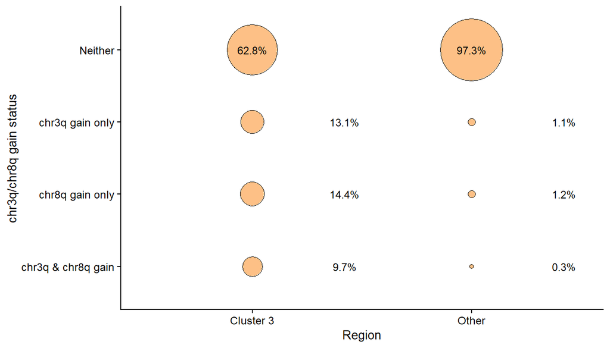

```r
# Bubble plot
bubble_df <- co_plot_sub %>%
  count(region, status) %>%
  group_by(region) %>%
  mutate(Percentage = 100 * n / sum(n)) %>%
  ungroup()

# Figure 4D: Enrichments bubble plot
bubble_df$status <- factor(
  bubble_df$status,
  levels = c("chr3q & chr8q gain",
    "chr8q gain only",
    "chr3q gain only",
    "Neither"))

ggplot(bubble_df, aes(x = region, y = status, size = Percentage)) +
  geom_point(shape = 21,fill = "#fdc086", colour = "black") +
  geom_text(data = subset(bubble_df, Percentage >= 20),
    aes(label = sprintf("%.1f%%", Percentage)),
    size = 3) +
  geom_text(data = subset(bubble_df, Percentage < 20),
    aes(label = sprintf("%.1f%%", Percentage)),
    size = 3,
    nudge_x = 0.42) +
  scale_size_area(max_size = 24,name = "Percentage") +
  labs(x = "Region", y = "chr3q/chr8q gain status") +
  theme_classic() +
  theme(axis.text.x=element_text(colour="black", size=9)) +
  theme(axis.text.y=element_text(colour="black", size=9)) +
  theme(axis.title.y=element_text(colour="black", size=10)) +
   theme(axis.title.x=element_text(colour="black", size=10))+
    theme(legend.position = "none",
    legend.title = element_blank(),
    legend.text = element_text(size = 7))
```

```r
# Figure 4D: Odds ratios forest plot
forest_df <- data.frame(
  Feature = c(
    "Neither",
    "chr3q gain only",
    "chr8q gain only",
    "chr3q & chr8q gain"
  ),
  OR = c(
    unname(ft_neither$estimate),
    unname(ft_chr3$estimate),
    unname(ft_chr8$estimate),
    unname(ft_both$estimate)
  ),
  Lower = c(
    ft_neither$conf.int[1],
    ft_chr3$conf.int[1],
    ft_chr8$conf.int[1],
    ft_both$conf.int[1]
  ),
  Upper = c(
    ft_neither$conf.int[2],
    ft_chr3$conf.int[2],
    ft_chr8$conf.int[2],
    ft_both$conf.int[2]
  ),
  P = c(
    ft_neither$p.value,
    ft_chr3$p.value,
    ft_chr8$p.value,
    ft_both$p.value
  )
)

forest_df
```

```
##              Feature          OR       Lower       Upper             P
## 1            Neither  0.04728715  0.04029439  0.05553651 6.620812e-230
## 2    chr3q gain only 19.44819566 16.04571607 23.51150192 1.466400e-142
## 3    chr8q gain only 19.77588313 16.38902347 23.81469995 7.789736e-151
## 4 chr3q & chr8q gain 30.52766786 22.44863722 41.36654072  7.437260e-75
```

```r
tabletext <- cbind(
  c( forest_df$Feature),
  c( rep("", nrow(forest_df))),
  c(paste0(sprintf("%.2f", forest_df$OR),
      " (", sprintf("%.2f", forest_df$Lower),
      "–",sprintf("%.2f", forest_df$Upper),")")),
  c(ifelse( forest_df$P < 2.2e-16, "<2.2 × 10⁻¹⁶",sprintf("%.2e", forest_df$P))))
```